# Background and Context

There is a huge demand for used cars in the Indian Market today. As sales of new cars have slowed down in the recent past, the pre-owned car market has continued to grow over the past years and is larger than the new car market now. Cars4U is a budding tech start-up that aims to find footholes in this market.

In 2018-19, while new car sales were recorded at 3.6 million units, around 4 million second-hand cars were bought and sold. There is a slowdown in new car sales and that could mean that the demand is shifting towards the pre-owned market. In fact, some car sellers replace their old cars with pre-owned cars instead of buying new ones. Unlike new cars, where price and supply are fairly deterministic and managed by OEMs (Original Equipment Manufacturer / except for dealership level discounts which come into play only in the last stage of the customer journey), used cars are very different beasts with huge uncertainty in both pricing and supply. Keeping this in mind, the pricing scheme of these used cars becomes important in order to grow in the market.

# Objective

1. Explore and visualize the dataset.
2. Build a linear regression model to predict the prices of used cars.
3. Generate a set of insights and recommendations that will help the business.

# Variables to be analyzed

1. .No. : Serial Number
2. Name : Name of the car which includes Brand name and Model name
3. Location : The location in which the car is being sold or is available for purchase Cities
4. Year : Manufacturing year of the car
5. Kilometers_driven : The total kilometers driven in the car by the previous owner(s) in KM.
6. Fuel_Type : The type of fuel used by the car. (Petrol, Diesel, Electric, CNG, LPG)
7. Transmission : The type of transmission used by the car. (Automatic / Manual)
8. Owner : Type of ownership
9. Mileage : The standard mileage offered by the car company in kmpl or km/kg
10. Engine : The displacement volume of the engine in CC.
11. Power : The maximum power of the engine in bhp.
12. Seats : The number of seats in the car.
13. New_Price : The price of a new car of the same model in INR Lakhs.(1 Lakh = 100, 000)
14. Price : The price of the used car in INR Lakhs (1 Lakh = 100, 000)

# Importing modules and packages

```python
#import the important packages
import warnings
warnings.filterwarnings('ignore')
import pandas as pd #library used for data manipulation and analysis
import numpy as np # library used for working with arrays.
import matplotlib.pyplot as plt # library for plots and visualisations
import seaborn as sns # library for visualisations
import random
from sklearn.model_selection import train_test_split
from sklearn.preprocessing import PolynomialFeatures
from sklearn import linear_model
from scipy.stats import pearsonr
%matplotlib inline

import scipy.stats as stats # this library contains a large number of probability distributions as well as a growing library of
```

# Reading and pre-processing the data

```python
data = pd.read_csv('used_cars_data.csv', index_col = 0) #reading the data
np.random.seed(1)
data.sample(n = 10) #random sample of 10 values
```

| S.No. | Name | Location | Year | Kilometers_Driven | Fuel_Type | Transmission | Owner_Type | Mileage | Engine | Power | Seats | New_Price | Price |
| --- | --- | --- | --- | --- | --- | --- | --- | --- | --- | --- | --- | --- | --- |
| 2397 | Ford EcoSport 1.5 Petrol Trend | Kolkata | 2016 | 21460 | Petrol | Manual | First | 17.0 kmpl | 1497 CC | 121.36 bhp | 5.0 | 9.47 Lakh | 6.00 |
| 3777 | Maruti Wagon R VXI 1.2 | Kochi | 2015 | 49818 | Petrol | Manual | First | 21.5 kmpl | 1197 CC | 81.80 bhp | 5.0 | 5.44 Lakh | 4.11 |
| 4425 | Ford Endeavour 4x2 XLT | Hyderabad | 2007 | 130000 | Diesel | Manual | First | 13.1 kmpl | 2499 CC | 141 bhp | 7.0 | NaN | 6.00 |
| 3661 | Mercedes-Benz E-Class E250 CDI Avantgrade | Coimbatore | 2016 | 39753 | Diesel | Automatic | First | 13.0 kmpl | 2143 CC | 201.1 bhp | 5.0 | NaN | 35.28 |
| 4514 | Hyundai Xcent 1.2 Kappa AT SX Option | Kochi | 2016 | 45560 | Petrol | Automatic | First | 16.9 kmpl | 1197 CC | 82 bhp | 5.0 | NaN | 6.34 |
| 599 | Toyota Innova Crysta 2.8 ZX AT | Coimbatore | 2019 | 40674 | Diesel | Automatic | First | 11.36 kmpl | 2755 CC | 171.5 bhp | 7.0 | 28.05 Lakh | 24.82 |
| 186 | Mercedes-Benz E-Class E250 CDI Avantgrade | Bangalore | 2014 | 37382 | Diesel | Automatic | First | 13.0 kmpl | 2143 CC | 201.1 bhp | 5.0 | NaN | 32.00 |
| 305 | Audi A6 2011-2015 2.0 TDI Premium Plus | Kochi | 2014 | 61726 | Diesel | Automatic | First | 17.68 kmpl | 1968 CC | 174.33 bhp | 5.0 | NaN | 20.77 |
| 4582 | Hyundai i20 1.2 Magna | Kolkata | 2011 | 36000 | Petrol | Manual | First | 18.5 kmpl | 1197 CC | 80 bhp | 5.0 | NaN | 2.50 |
| 5434 | Honda WR-V Edge Edition i-VTEC S | Kochi | 2019 | 13913 | Petrol | Manual | First | 17.5 kmpl | 1199 CC | 88.7 bhp | 5.0 | 9.36 Lakh | 8.20 |

```python
data.shape  #the shape of the data
```

```
(7253, 13)
```

```python
data.info() #info of all the variables
```

```
<class 'pandas.core.frame.DataFrame'>
Int64Index: 7253 entries, 0 to 7252
Data columns (total 13 columns):
 #   Column             Non-Null Count  Dtype
---  ------             --------------  -----
 0   Name               7253 non-null   object
 1   Location           7253 non-null   object
 2   Year               7253 non-null   int64
 3   Kilometers_Driven  7253 non-null   int64
 4   Fuel_Type          7253 non-null   object
 5   Transmission       7253 non-null   object
 6   Owner_Type         7253 non-null   object
 7   Mileage            7251 non-null   object
 8   Engine             7207 non-null   object
 9   Power              7207 non-null   object
 10  Seats              7200 non-null   float64
 11  New_Price          1006 non-null   object
 12  Price              6019 non-null   float64
dtypes: float64(2), int64(2), object(9)
memory usage: 793.3+ KB
```

Observation:

1. Based on the above data types, Mileage, Engine, Power and New_Price have to be changed to float values
2. Name variable column can be further analyzed into useful data.
3. Year should be changed into date time/integer value or it can be changed into the age of the car since manfucturing till 2020.

```python
data.isnull().sum().sort_values(ascending=False) #sum of all the null values per variable
```

```
New_Price            6247
Price                1234
Seats                  53
Power                  46
Engine                 46
Mileage                 2
Owner_Type              0
Transmission            0
Fuel_Type               0
Kilometers_Driven       0
Year                    0
Location                0
Name                    0
dtype: int64
```

```python
data.drop(['New_Price'], axis = 1, inplace = True) #droppung the new_price variable
```

Observation:

```python
def mileage_to_num(input): #converitng mileage to a number
    if isinstance(input, str):
        if input.split()[1] == 'km/kg':
            return float(input.replace('km/kg', ''))
        else:
            return float(input.replace('kmpl', ''))
    else:
        return np.nan


def engine_to_num(input): #converting engine to a number value
    if isinstance(input, str):
        return float(input.replace('CC', ''))
    else:
        return np.nan


def power_to_num(input): #converting power to a number value
    if isinstance(input, str):
        if input.split()[0] == 'null':
            return np.nan
        else:
            return float(input.replace('bhp', ''))
    else:
        return np.nan


def nprice_to_num(input):
    if isinstance(input, str):
        if input.split()[1] == 'Lakh':
            return float(input.replace('Lakh', ''))
        else:
            return float(input.replace('Cr', '')) * 100
    else:
        return np.nan
```

```python
col_transforms = {
    'Mileage': mileage_to_num,
    'Engine': engine_to_num,
    'Power': power_to_num,
}
 #making a ddictiornary of all variables to be converted paired withe appropriate function
# k is the key, so the column name here

# v is the value, which a function in this case and is
#     either `height_to_num` or `weight_to_num`
for k,v in col_transforms.items():
    data[k] = data[k].map(v)
```

```python
data.info() #checking the data info now
```

```
<class 'pandas.core.frame.DataFrame'>
Int64Index: 7253 entries, 0 to 7252
Data columns (total 12 columns):
 #   Column             Non-Null Count  Dtype
---  ------             --------------  -----
 0   Name               7253 non-null   object
 1   Location           7253 non-null   object
 2   Year               7253 non-null   int64
 3   Kilometers_Driven  7253 non-null   int64
 4   Fuel_Type          7253 non-null   object
 5   Transmission       7253 non-null   object
 6   Owner_Type         7253 non-null   object
 7   Mileage            7251 non-null   float64
 8   Engine             7207 non-null   float64
 9   Power              7078 non-null   float64
 10  Seats              7200 non-null   float64
 11  Price              6019 non-null   float64
dtypes: float64(5), int64(2), object(5)
memory usage: 736.6+ KB
```

```python
new_name  = [i.split()[0] for i in data.Name] #clearing up the Name column
data.Name = new_name
```

```python
age_cars = [(2020 - i) for i in data.Year] #Changing the Year column to Age of cars
data.Year = age_cars
data = data.rename(columns={'Year': 'Age_of_Car'})
```

```python
data.nunique(dropna = False) #unique values from each variable
```

```
Name                   33
Location               11
Age_of_Car             23
Kilometers_Driven    3660
Fuel_Type               5
Transmission            2
Owner_Type              4
Mileage               439
Engine                151
Power                 384
Seats                  10
Price                1374
dtype: int64
```

```python
data.isnull().sum().sort_values(ascending=False) #checking the total number of null values per variable
```

```
Price                1234
Power                 175
Seats                  53
Engine                 46
Mileage                 2
Owner_Type              0
Transmission            0
Fuel_Type               0
Kilometers_Driven       0
Age_of_Car              0
Location                0
Name                    0
dtype: int64
```

```python
data.isnull().sum(axis=1).value_counts() #null values per row
```

```
0    5872
1    1308
3      36
2      27
4      10
dtype: int64
```

```python
num_missing = data.isnull().sum(axis=1) #storing null values per row into num_missing
num_missing.value_counts()
```

```
0    5872
1    1308
3      36
2      27
4      10
dtype: int64
```

```python
# these are missing of Power, Seats and/or Price
data[num_missing == 2].sample(n=5)
```

| S.No. | Name | Location | Age_of_Car | Kilometers_Driven | Fuel_Type | Transmission | Owner_Type | Mileage | Engine | Power | Seats | Price |
| --- | --- | --- | --- | --- | --- | --- | --- | --- | --- | --- | --- | --- |
| 6723 | Ford | Kolkata | 11 | 39408 | Diesel | Manual | First | 17.80 | 1399.0 | NaN | 5.0 | NaN |
| 3882 | Maruti | Kolkata | 10 | 40000 | Petrol | Manual | Second | 19.50 | 1061.0 | NaN | NaN | 2.50 |
| 6957 | Honda | Kochi | 1 | 11574 | Petrol | Manual | First | 0.00 | 1199.0 | 88.7 | NaN | NaN |
| 6896 | Toyota | Hyderabad | 7 | 86000 | Diesel | Manual | First | 23.59 | 1364.0 | NaN | 5.0 | NaN |
| 5893 | Maruti | Chennai | 12 | 51000 | Petrol | Manual | Second | 19.50 | 1061.0 | NaN | NaN | 1.75 |

```python
# these are missing Engine, Power and Seats
data[num_missing == 3].sample(n=5)
```

| S.No. | Name | Location | Age_of_Car | Kilometers_Driven | Fuel_Type | Transmission | Owner_Type | Mileage | Engine | Power | Seats | Price |
| --- | --- | --- | --- | --- | --- | --- | --- | --- | --- | --- | --- | --- |
| 4604 | Honda | Pune | 9 | 98000 | Petrol | Manual | First | 16.70 | NaN | NaN | NaN | 3.15 |
| 2780 | Hyundai | Pune | 11 | 100000 | Petrol | Manual | First | 0.00 | NaN | NaN | NaN | 1.60 |
| 4577 | BMW | Delhi | 8 | 72000 | Diesel | Automatic | Third | 18.48 | NaN | NaN | NaN | 13.85 |
| 194 | Honda | Ahmedabad | 13 | 60006 | Petrol | Manual | First | 0.00 | NaN | NaN | NaN | 2.95 |
| 2530 | BMW | Kochi | 6 | 64158 | Diesel | Automatic | First | 18.48 | NaN | NaN | NaN | 17.89 |

```python
# these are missing Engine, Power, Seats, Price
data[num_missing == 4].sample(n=10)
```

| S.No. | Name | Location | Age_of_Car | Kilometers_Driven | Fuel_Type | Transmission | Owner_Type | Mileage | Engine | Power | Seats | Price |
| --- | --- | --- | --- | --- | --- | --- | --- | --- | --- | --- | --- | --- |
| 6633 | Mahindra | Kolkata | 4 | 27000 | Diesel | Manual | First | 0.00 | NaN | NaN | NaN | NaN |
| 6643 | BMW | Bangalore | 11 | 150000 | Diesel | Automatic | Second | 18.48 | NaN | NaN | NaN | NaN |
| 6651 | Maruti | Kolkata | 5 | 36009 | Petrol | Manual | First | 16.10 | NaN | NaN | NaN | NaN |
| 6042 | Skoda | Bangalore | 11 | 72000 | Petrol | Manual | Second | 17.50 | NaN | NaN | NaN | NaN |
| 6677 | Fiat | Jaipur | 10 | 65000 | Petrol | Manual | Third | 14.60 | NaN | NaN | NaN | NaN |
| 6880 | BMW | Chennai | 11 | 95000 | Diesel | Automatic | Second | 18.48 | NaN | NaN | NaN | NaN |
| 6902 | Toyota | Kochi | 8 | 59311 | Petrol | Manual | First | 18.30 | NaN | NaN | NaN | NaN |
| 6541 | Toyota | Bangalore | 8 | 56600 | Diesel | Manual | First | 23.59 | NaN | NaN | NaN | NaN |
| 6544 | Hyundai | Bangalore | 8 | 58000 | Petrol | Automatic | Second | 15.00 | NaN | NaN | NaN | NaN |
| 6685 | Maruti | Pune | 10 | 115000 | Petrol | Manual | Second | 16.10 | NaN | NaN | NaN | NaN |

```python
for n in num_missing.value_counts().sort_index().index: #printing out where the variables are gone missing
    if n > 0:
        print(f'For the rows with exactly {n} missing values, NAs are found in:')
        n_miss_per_col = data[num_missing == n].isnull().sum()
        print(n_miss_per_col[n_miss_per_col > 0])
        print('\n\n')
```

```
For the rows with exactly 1 missing values, NAs are found in:
Mileage       2
Power       103
Seats         2
Price      1201
dtype: int64



For the rows with exactly 2 missing values, NAs are found in:
Power    26
Seats     5
Price    23
dtype: int64



For the rows with exactly 3 missing values, NAs are found in:
Engine    36
Power     36
Seats     36
dtype: int64



For the rows with exactly 4 missing values, NAs are found in:
Engine    10
Power     10
Seats     10
Price     10
dtype: int64
```

```python
data['Name'] = data['Name'].astype('category')
data['Location'] = data['Location'].astype('category')
data['Fuel_Type'] = data['Fuel_Type'].astype('category') #converting to categorical variables
data['Transmission'] = data['Transmission'].astype('category')
data['Owner_Type'] = data['Owner_Type'].astype('category')
data['Location'] = data['Location'].astype('category')
```

```python
data['Engine'].fillna(data['Engine'].median(), inplace=True)  # median imputation
data['Power'].fillna(data['Power'].median(), inplace=True)
data['Mileage'].fillna(data['Mileage'].median(), inplace=True)
data['Price'].fillna(data['Price'].median(), inplace=True)
data['Seats'].fillna(data['Seats'].median(), inplace=True)
```

```python
void_list = ['Engine', 'Power', 'Mileage', 'Price', 'Seats']  #checking the null values again
for i in void_list: #checking if all the null values have been filled
    print(f'{i} null values are: {data[i].isnull().sum()}')
```

```
Engine null values are: 0
Power null values are: 0
Mileage null values are: 0
Price null values are: 0
Seats null values are: 0
```

```python
data.isnull().sum().sort_values(ascending=False)
```

```
Price                0
Seats                0
Power                0
Engine               0
Mileage              0
Owner_Type           0
Transmission         0
Fuel_Type            0
Kilometers_Driven    0
Age_of_Car           0
Location             0
Name                 0
dtype: int64
```

```python
print(data.describe().T) #statistics of all the variables
```

[output not shown]

Observation:

1. Age of car may be normally distributed as mean is very close to the median
2. Mileage is normally distributed as mean and median are equal.
3. For kilometers driven there is a huge range in the data
4. Power and Price huge range in data

```python
print(data.describe(include = 'category')) #categorical variables statistics
```

```
          Name Location Fuel_Type Transmission Owner_Type
count     7253     7253      7253         7253       7253
unique      33       11         5            2          4
top     Maruti   Mumbai    Diesel       Manual      First
freq      1444      949      3852         5204       5952
```

Observation:

1. There are 10 unique values for seats, with 5 being the most common, which makes sense.
2. Interesting that there are 5 differnt Fuel_Type cars, with disel being the most common
3. Only two types of transmission, which makes sense.
4. A car can have more than 4 owners which is very small as compared to the other values in the owner column

# EDA

```python
def histogram_boxplot(feature):
    """ Boxplot and histogram combined
    feature: 1-d feature array
    """
    figure, (ax_box2, ax_hist2, ax_hist3) = plt.subplots(
        nrows = 1, ncols=3,# Number of rows of the subplot grid= 2
        figsize  = (20,5)) # creating the 2 subplots
    figure.tight_layout(pad = 7)
    sns.boxplot(x = feature,ax=ax_box2, color = '#4B8BBE', orient = 'v') # boxplot will be created
    sns.distplot(feature, kde=True, ax=ax_hist2, color = '#a9a38f') # For histogram
    sns.distplot(feature, kde= True, ax=ax_hist3, hist = False) #Making an outline of the histogram
    ax_hist2.axvline(np.mean(feature), color='r', linestyle='--') # Add mean to the histogram
    ax_hist2.axvline(np.median(feature), color='black', linestyle='-') # Add median to the histogram
    ax_hist3.axvline(np.mean(feature), color = 'black', linestyle = '--') #Adding mean to second histogram
    ax_hist3.axvline(np.median(feature), color='black', linestyle='-') #Adding median to second histogram
```

## Observations on Age of Car

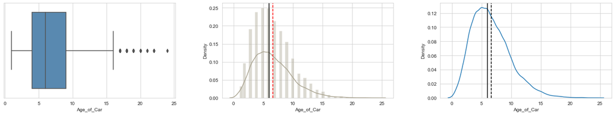

```python
histogram_boxplot(data.Age_of_Car)
```

Observation:

1. There are some outliers
2. The graph is right skewed.

### Observations on Kilometeres Driven

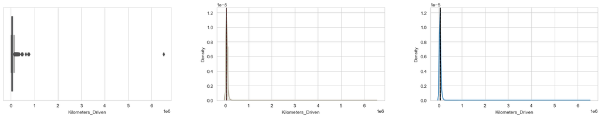

```python
histogram_boxplot(data['Kilometers_Driven'])
```

Observation:

1. Heavily right skewed graph
2. Maybe log scale transformation/arcsinh transformation may be applicable here.
3. There is clearly one distinct outlier

### Observations on Mileage

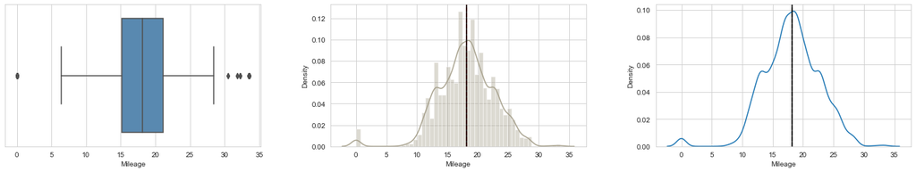

```python
histogram_boxplot(data['Mileage'])
```

Observation:

1. One outlier towards the low end and few outliers towards the right side.
2. Not accounting for the outlier, the graph looks normally distributed.

### Observations on Engine

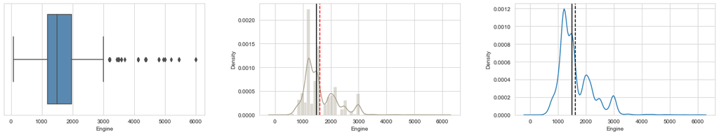

```python
histogram_boxplot(data['Engine'])
```

Observation:

### Observations on Power

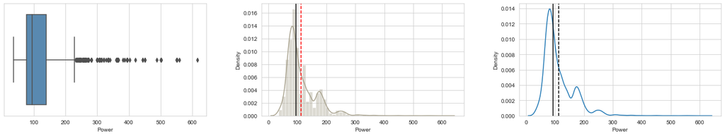

```python
histogram_boxplot(data['Power'])
```

Observation:

1. Numerous Outliers present.
2. Heavily right skewed graph.
3. Outlier treatment like dropping outliers need to be considered.

### Observations on Price

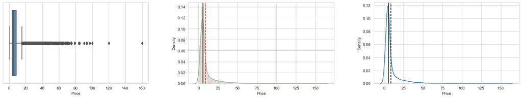

```python
histogram_boxplot(data['Price'])
```

Observations:

1. Numerous outliers seen.
2. Right Skewed graph.
3. Log transformation can be completed along with outlier treatments.

### Observation on Seats

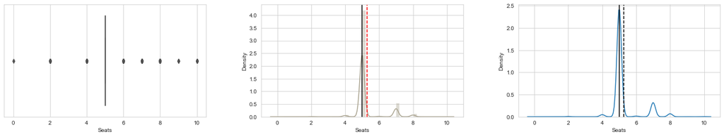

```python
histogram_boxplot(data['Seats'])
```

Observation:

## Applying Log and Arcsinh Transformations

### Transformation for Kilometers Driven

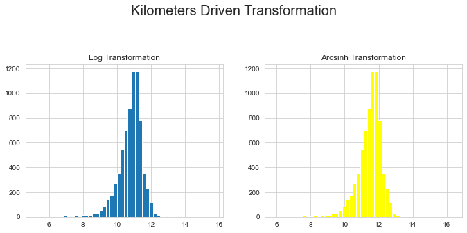

```python
fig, axs = plt.subplots(1, 2, figsize=(10,5)) #making a subplot
axs[0].hist(x = np.log(data['Kilometers_Driven']), bins = 50) #log transformation of km driven
axs[0].set_title('Log Transformation')
axs[1].hist(x = np.arcsinh(data['Kilometers_Driven']), bins = 50, color = 'yellow') #arcsinh transformation of km driven
axs[1].set_title('Arcsinh Transformation')
plt.suptitle('Kilometers Driven Transformation',fontsize=20)
fig.tight_layout(pad=3.0)
plt.show()
```

Observations:

1. The log and arcsinh look similar so the difference there is more be about interpretation.
2. The log transformation decreases the scale of the distributions, even with the huge range of Kilometeters driven. It seems the outliers caused the log-transformed distributions to still be a bit skewed, but it is closer to normal than the original distribution.

### Transformation for Price

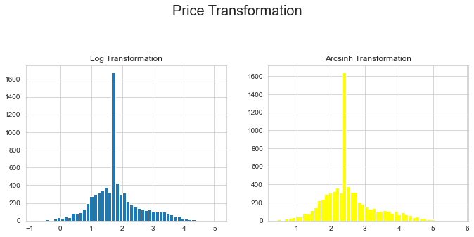

```python
fig, axs = plt.subplots(1, 2, figsize=(10,5)) #making a subplot
axs[0].hist(x = np.log(data['Price']), bins = 50) #log transformation of km driven
axs[0].set_title('Log Transformation')
axs[1].hist(x = np.arcsinh(data['Price']), bins = 50, color = 'yellow') #arcsinh transformation of km driven
axs[1].set_title('Arcsinh Transformation')
plt.suptitle('Price Transformation',fontsize=20)
fig.tight_layout(pad=3.0)
plt.show()
```

Observations:

1. The log and arcsinh look similar so the difference there is more be about interpretation.
2. There is onviously one value that is very different from others.
3. Maybe removing tht one huge value the graph may look more normally distributed.

### Transformations for Seats

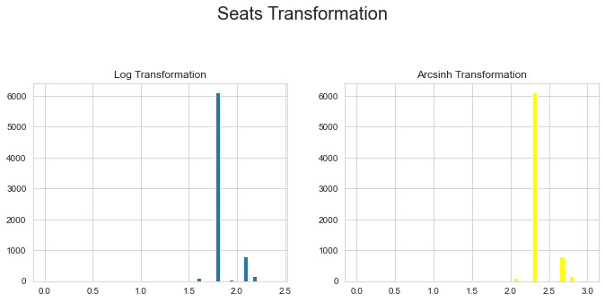

```python
fig, axs = plt.subplots(1, 2, figsize=(10,5)) #making a subplot
axs[0].hist(x = np.log(data['Seats'] + 1), bins = 50) #log transformation of seats
axs[0].set_title('Log Transformation')
axs[1].hist(x = np.arcsinh(data['Seats']), bins = 50, color = 'yellow') #arcsinh transformation of seats
axs[1].set_title('Arcsinh Transformation')
plt.suptitle('Seats Transformation',fontsize=20)
fig.tight_layout(pad=3.0)
plt.show()
```

Observations:

1. From the above, there were a lot of 0 values so log(value + 1) transformation has to be applied.
2. There dosen't seem to be a big change in either of the two graphs, the outliers are pushing the graph to be more left skewed than previous graph.

## Outlier treatments

```python
# Let's treat outliers by flooring and capping
def treat_outliers(df, col):
    """
    treats outliers in a variable
    col: str, name of the numerical variable
    df: dataframe
    col: name of the column
    """
    Q1 = df[col].quantile(0.25)  # 25th quantile
    Q3 = df[col].quantile(0.75)  # 75th quantile
    IQR = Q3 - Q1
    Lower_Whisker = Q1 - 1.5 * IQR
    Upper_Whisker = Q3 + 1.5 * IQR

    # all the values smaller than Lower_Whisker will be assigned the value of Lower_Whisker
    # all the values greater than Upper_Whisker will be assigned the value of Upper_Whisker
    df[col] = np.clip(df[col], Lower_Whisker, Upper_Whisker)

    return df


def treat_outliers_all(df, col_list):
    """
    treat outlier in all numerical variables
    col_list: list of numerical variables
    df: data frame
    """
    for c in col_list:
        df = treat_outliers(df, c)

    return df
```

```python
numeric_columns = data.select_dtypes(include=np.number).columns.tolist()#numberic columns
numerical_col = data.select_dtypes(include=np.number).columns.tolist()#converting numerical cols
data = treat_outliers_all(data, numerical_col) #treating outliers
```

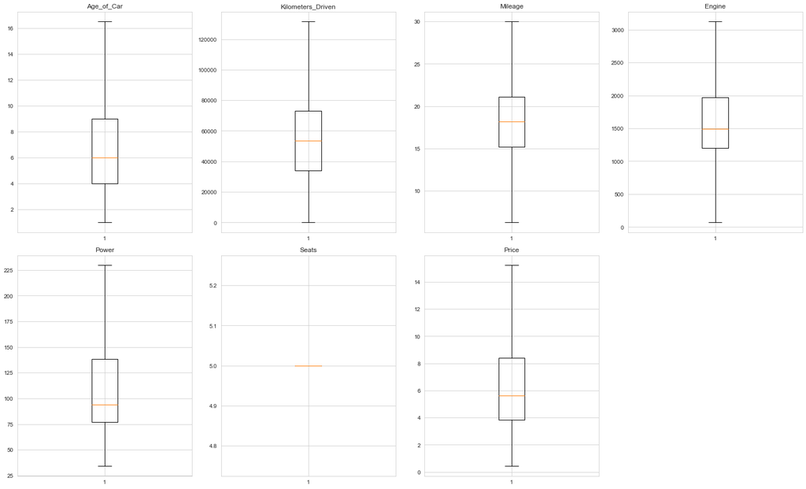

```python
plt.figure(figsize=(20, 30))

for i, variable in enumerate(numeric_columns): #boxplots subplots
    plt.subplot(5, 4, i + 1)
    plt.boxplot(data[variable], whis=1.5)
    plt.tight_layout()
    plt.title(variable)

plt.show()
```

Observation:

1. As it can be seen above, all outliers has been treated and no outliers remain.
2. The graph for seats only appear to be a straight line, or all the points seem to be at 5 seats.

```python
data['Name'] = data['Name'].astype('category')
data['Location'] = data['Location'].astype('category')
data['Fuel_Type'] = data['Fuel_Type'].astype('category') #converting to categorical variables
data['Transmission'] = data['Transmission'].astype('category')
data['Owner_Type'] = data['Owner_Type'].astype('category')
data['Location'] = data['Location'].astype('category')
```

## Categorical Variables

```python
def bar_perc(plot, feature):
    '''
    plot
    feature: 1-d categorical feature array
    '''
    total = len(feature) # length of the column
    for p in ax.patches:
        percentage = '{:.1f}%'.format(100 * p.get_height()/total) # percentage of each class of the category
        x = p.get_x() + p.get_width() / 2 - 0.05 # width of the plot
        y = p.get_y() + p.get_height()           # hieght of the plot
        ax.annotate(percentage, (x, y), size = 12) # annotate the percantage
```

### Observations on Name

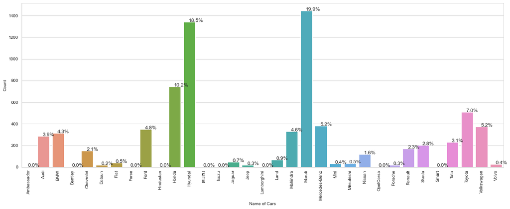

```python
plt.figure(figsize=(20,7))
ax = sns.countplot(data['Name']) #count plot for Name
plt.xlabel('Name of Cars')
plt.xticks(rotation=90)
plt.ylabel('Count')
bar_perc(ax,data['Name'])
```

Observations:

### Observations on Location

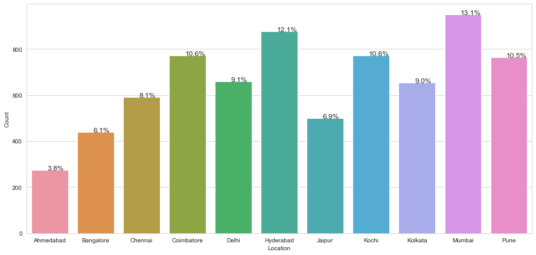

```python
plt.figure(figsize=(15,7))
ax = sns.countplot(data['Location']) #count plot for Location
plt.xlabel('Location')
plt.ylabel('Count')
bar_perc(ax,data['Location'])
```

Observation:

1. Mumbai and Hyderbad are the most common Locations.
2. The least common location is Ahmedabad

### Observation on Fuel Type

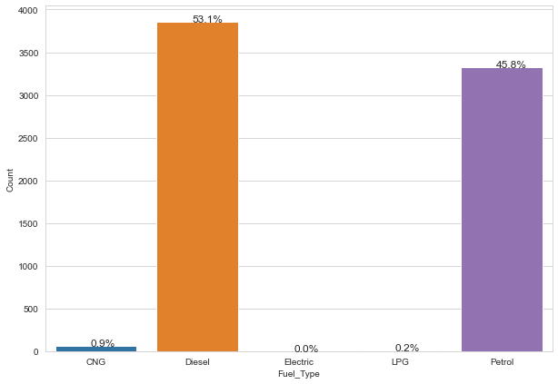

```python
plt.figure(figsize=(10,7))
ax = sns.countplot(data['Fuel_Type'])
plt.xlabel('Fuel_Type')
plt.ylabel('Count')
bar_perc(ax,data['Fuel_Type'])
```

Observation:

1. The most common type of Fuel is Diesel with 53.1% followed by petrol 45.8%
2. The least common fuel type is the electric car, there was only 2 values of electric car in the whole data.

### Observation on Transmission Type

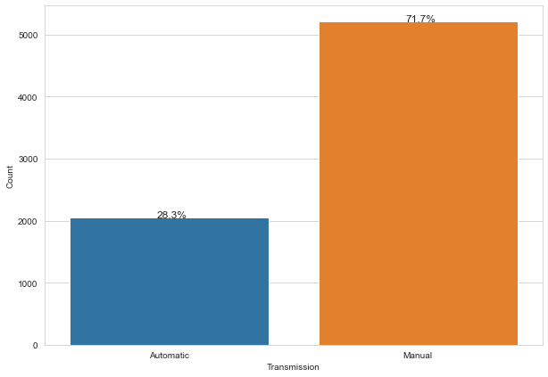

```python
plt.figure(figsize=(10,7))
ax = sns.countplot(data['Transmission'])
plt.xlabel('Transmission')
plt.ylabel('Count')
bar_perc(ax,data['Transmission'])
```

Observation:

1. Manual is the most common type of transmission with 71.%
2. Automatic is the least common type of transmission

### Observation on Owner Type

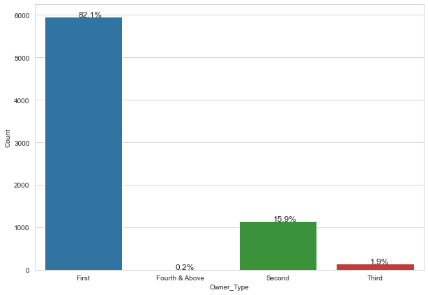

```python
plt.figure(figsize=(10,7))
ax = sns.countplot(data['Owner_Type'])
plt.xlabel('Owner_Type')
plt.ylabel('Count')
bar_perc(ax,data['Owner_Type'])
```

Observation:

1. First hand owners are mostly popular with 82.1% with the least being 0.2%

## Bivariate Analysis

```python
data.corr() #correlation of data
```

|  | Age_of_Car | Kilometers_Driven | Mileage | Engine | Power | Seats | Price |
| --- | --- | --- | --- | --- | --- | --- | --- |
| Age_of_Car | 1.000000 | 0.519522 | -0.321942 | 0.049200 | -0.035288 | NaN | -0.371188 |
| Kilometers_Driven | 0.519522 | 1.000000 | -0.160162 | 0.186120 | 0.021601 | NaN | -0.152816 |
| Mileage | -0.321942 | -0.160162 | 1.000000 | -0.621567 | -0.539260 | NaN | -0.304916 |
| Engine | 0.049200 | 0.186120 | -0.621567 | 1.000000 | 0.846878 | NaN | 0.646981 |
| Power | -0.035288 | 0.021601 | -0.539260 | 0.846878 | 1.000000 | NaN | 0.727125 |
| Seats | NaN | NaN | NaN | NaN | NaN | NaN | NaN |
| Price | -0.371188 | -0.152816 | -0.304916 | 0.646981 | 0.727125 | NaN | 1.000000 |

```python
data.cov() #covariance of data
```

|  | Age_of_Car | Kilometers_Driven | Mileage | Engine | Power | Seats | Price |
| --- | --- | --- | --- | --- | --- | --- | --- |
| Age_of_Car | 10.231929 | 5.016561e+04 | -4.432510 | 8.871112e+01 | -5.186477 | 0.0 | -5.004103 |
| Kilometers_Driven | 50165.611008 | 9.112693e+08 | -20810.125109 | 3.167007e+06 | 29961.524356 | 0.0 | -19442.230069 |
| Mileage | -4.432510 | -2.081013e+04 | 18.526176 | -1.508044e+03 | -106.649682 | 0.0 | -5.531284 |
| Engine | 88.711119 | 3.167007e+06 | -1508.043931 | 3.177359e+05 | 21934.259628 | 0.0 | 1537.014171 |
| Power | -5.186477 | 2.996152e+04 | -106.649682 | 2.193426e+04 | 2111.240382 | 0.0 | 140.809224 |
| Seats | 0.000000 | 0.000000e+00 | 0.000000 | 0.000000e+00 | 0.000000 | 0.0 | 0.000000 |
| Price | -5.004103 | -1.944223e+04 | -5.531284 | 1.537014e+03 | 140.809224 | 0.0 | 17.762604 |

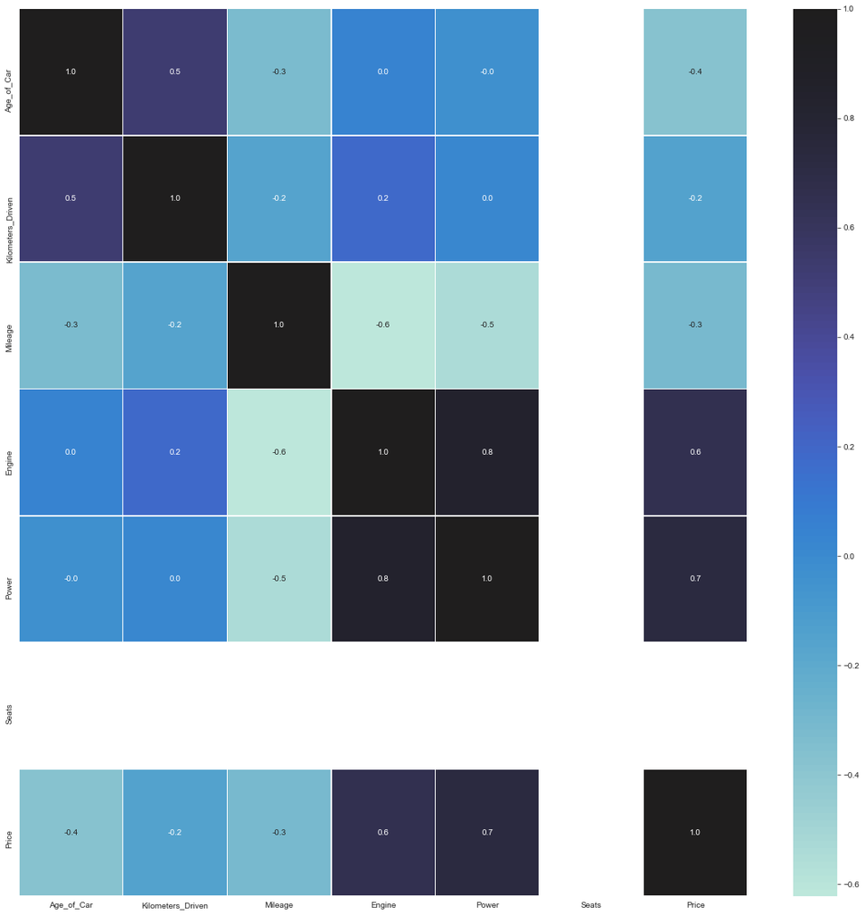

```python
plt.figure(figsize=(20,20))
sns.heatmap(data.corr(), annot=True, linewidths=.5, fmt= '.1f', center = 1 )  # heatmap
plt.show()
```

Observation:

1. Engine seems to have a high correlation with Price.
2. Power and Engine, Power and Price have high correlation
3. Seats and other variables don't really correlate well
4. Correlation does not imply cassaution.
5. Mileage and Engine correlate well negatively.

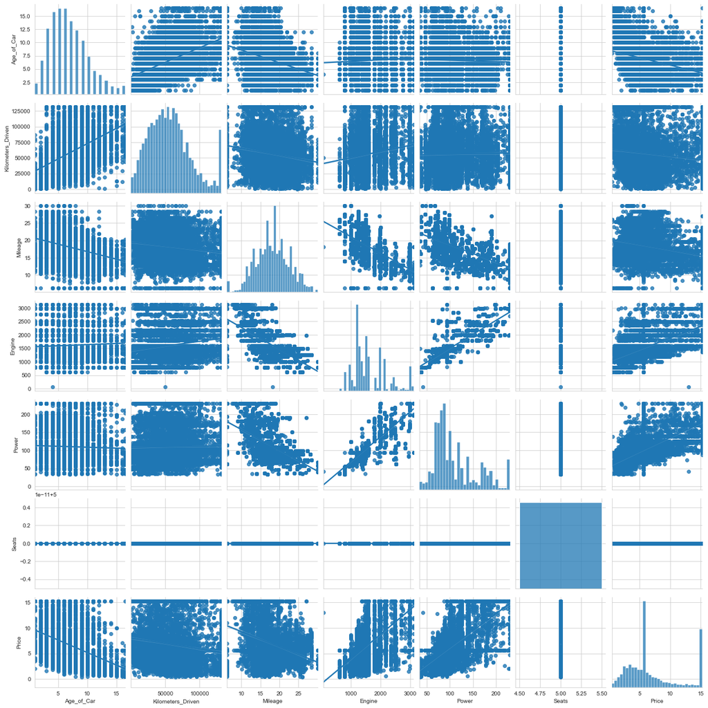

```python
plt.figure(figsize = (20,20))
sns.pairplot(data = data, kind = 'reg') #pairplot
plt.show()
```

Observation:

### Numerical vs Numerical

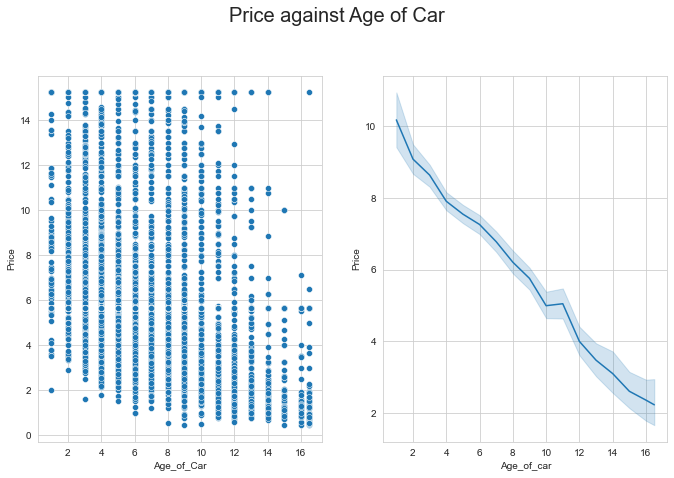

```python
fig, (ax1, ax2) = plt.subplots(1, 2, figsize=(10,7)) #creating subplots
ax1 = sns.scatterplot(x = 'Age_of_Car', ax = ax1,  y = 'Price', data = data) #scatterplot fo age vs price
ax2 = sns.lineplot(x = 'Age_of_Car', ax = ax2, y = 'Price', data = data) #lineplot of age vs price
plt.suptitle('Price against Age of Car',fontsize=20)
plt.xlabel('Age_of_car')
fig.tight_layout(pad=3.0)
plt.ylabel('Price')
```

Observation:

1. There is a negative correlation between price and age of car
2. The relationship may not be entirely linear but maybe of cubic or maybe quadratic.
3. There does seem to be distincive outliers.

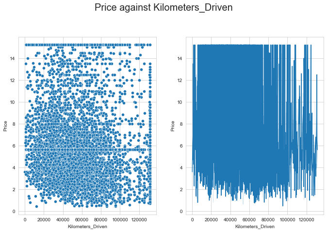

```python
fig, (ax1, ax2) = plt.subplots(1, 2, figsize=(10,7))
ax1 = sns.scatterplot(x = 'Kilometers_Driven', ax = ax1,  y = 'Price', data = data)
ax2 = sns.lineplot(x = 'Kilometers_Driven', ax = ax2, y = 'Price', data = data)
plt.suptitle('Price against Kilometers_Driven',fontsize=20)
plt.xlabel('Kilometers_Driven')
fig.tight_layout(pad=3.0)
plt.ylabel('Price')
```

Observations:

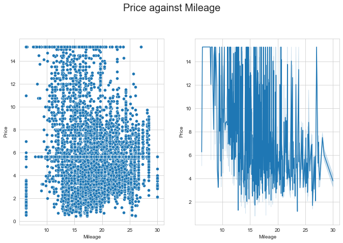

```python
fig, (ax1, ax2) = plt.subplots(1, 2, figsize=(10,7))
ax1 = sns.scatterplot(x = 'Mileage', ax = ax1,  y = 'Price', data = data)
ax2 = sns.lineplot(x = 'Mileage', ax = ax2, y = 'Price', data = data)
plt.suptitle('Price against Mileage',fontsize=20)
plt.xlabel('Mileage')
fig.tight_layout(pad=3.0)
plt.ylabel('Price')
```

Observations:

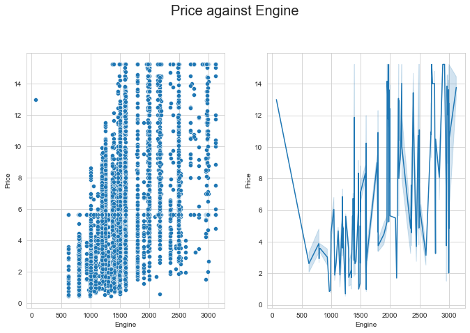

```python
fig, (ax1, ax2) = plt.subplots(1, 2, figsize=(10,7))
ax1 = sns.scatterplot(x = 'Engine', ax = ax1,  y = 'Price', data = data)
ax2 = sns.lineplot(x = 'Engine', ax = ax2, y = 'Price', data = data)
plt.suptitle('Price against Engine',fontsize=20)
plt.xlabel('Engine')
fig.tight_layout(pad=3.0)
plt.ylabel('Price')
```

Observations:

1. There is definitely a relationship between the two variables.
2. Positive correlation can be established between the two variables.
3. Although there is a rise in price as the engine values increase it, isn't a steady rise in relationship.

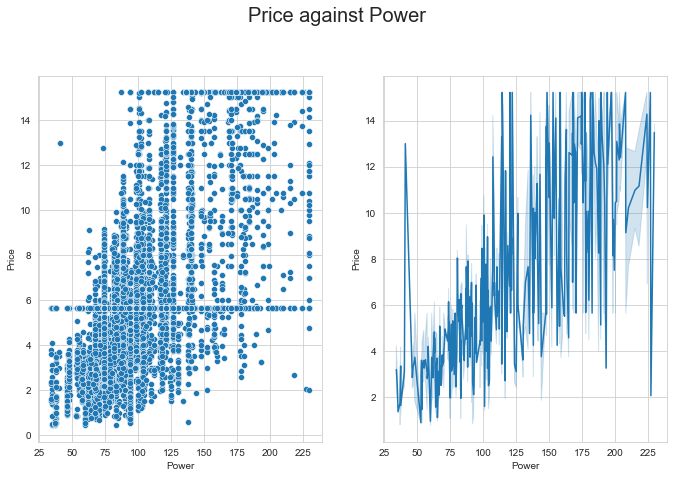

```python
fig, (ax1, ax2) = plt.subplots(1, 2, figsize=(10,7))
ax1 = sns.scatterplot(x = 'Power', ax = ax1,  y = 'Price', data = data)
ax2 = sns.lineplot(x = 'Power', ax = ax2, y = 'Price', data = data)
plt.suptitle('Price against Power',fontsize=20)
plt.xlabel('Power')
fig.tight_layout(pad=3.0)
plt.ylabel('Price')
```

Observation:

1. Power and price do correlate well.
2. Positive correlation shown by the two relationships.
3. There isn't a steady positive trend, rather many up and down's between the two variables.